# Platypus Quick Start

### 6.2 Visualizing clones on the 2 dimensional landscape

To better visualize this, the cells of any clone can also be highlighted on a dimensional reduction

Because the legend of these plots can get quite large, we can split the plot and the legend and draw them separately. For this the gridExtra and cowplot package is required

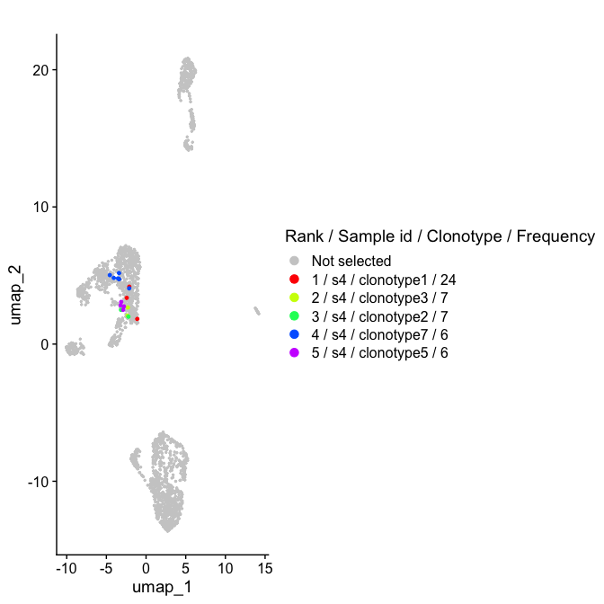

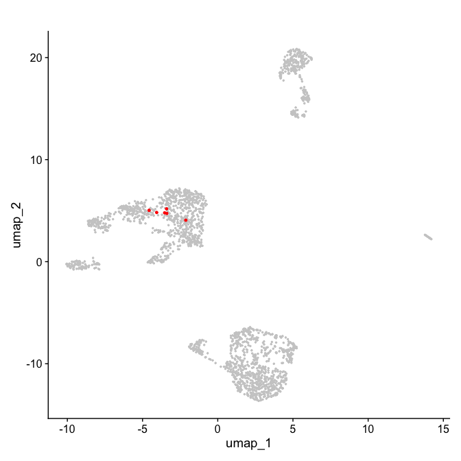

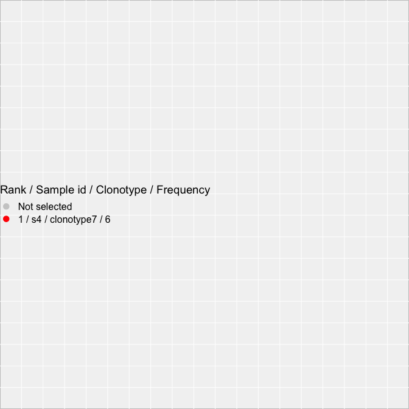

```r
#here we overlay the top 5 clones
plot_out <- VDJ_GEX_overlay_clones(GEX = VGM[[2]], reduction = "umap", n.clones = 5, by.sample = F, ncol.facet = 1, split.plot.and.legend = F, pt.size = 0.5)
plot_out[[1]] # the plot

#We can also plot any clone of interest by adding a column were TRUE values select which clones are to be plotted
interesting_clones <- c("clonotype7", "clonotype42")
VGM[[2]]@meta.data$clones_to_plot <- FALSE
VGM[[2]]@meta.data$clones_to_plot[which(VGM[[2]]$clonotype_id_10x %in% interesting_clones)] <- TRUE
plot_out <- VDJ_GEX_overlay_clones(GEX = VGM[[2]], reduction = "umap", clones.to.plot = "clones_to_plot", by.sample = F, ncol.facet = 1, split.plot.and.legend = T, pt.size = 0.5)
plot_out[[1]] # the plot
plot(plot_out[[2]]) # the legend. Alternatively use gridExtra::grid.arrange(plot_out[[2]])
```

### 6.3 Specific gene expression information on the clonal level

We previously integrated the GEX information into the format of the VDJ output. However, we may want to ask how the gene expression looks for certain clonotypes (e.g., how many of the cells in the top clone are expressing markers of activated B cells). This is done by adding an extra column to the VDJ and GEX objects containing binary information on expansion.

```r
VGM <- VGM_expanded_clones(VGM, add.to.VDJ = T, add.to.GEX = T, expansion.threshold = 2)
```

```
## Added new columns to VDJ: expanded_clonotype_frequency
```

```
## Added new columns to GEX: expanded_clonotype_frequency
```

```r
VGM[[2]] <- SeuratObject::JoinLayers(VGM[[2]])
```

For a more unbiased view, DEGs can be calculated between expanded and non-expanded clones

```r
DE_byexpansion <- GEX_DEgenes(GEX = VGM[[2]], min.pct = 0.25, group1 = "TRUE", group2 = "FALSE", grouping.column = "expanded_clonotype_frequency", return.plot = "volcano", logFC = F, label.n.top.genes = 5)
head(DE_byexpansion[[1]])
```

```
##                   p_val avg_logFC pct.1 pct.2   p_val_adj     SYMBOL
## Zc3h15     1.501698e-07 -6.650521 0.000 0.309 0.004757529     Zc3h15
## Ccr7       3.843845e-07 -1.552368 0.129 0.515 0.012177684       Ccr7
## Tspan13    8.735331e-07 -1.692454 0.071 0.412 0.027674401    Tspan13
## Pde4b      1.116669e-06 -1.349421 0.143 0.528 0.035377178      Pde4b
## AC149090.1 1.681616e-06 -6.815884 0.000 0.266 0.053275287 AC149090.1
## Gimap6     1.761742e-06 -1.094514 0.200 0.601 0.055813735     Gimap6
##            signif_pval signif_logfc color_threshold
## Zc3h15            TRUE         TRUE            TRUE
## Ccr7             FALSE         TRUE           FALSE
## Tspan13          FALSE         TRUE           FALSE
## Pde4b            FALSE         TRUE           FALSE
## AC149090.1       FALSE         TRUE           FALSE
## Gimap6           FALSE         TRUE           FALSE
```

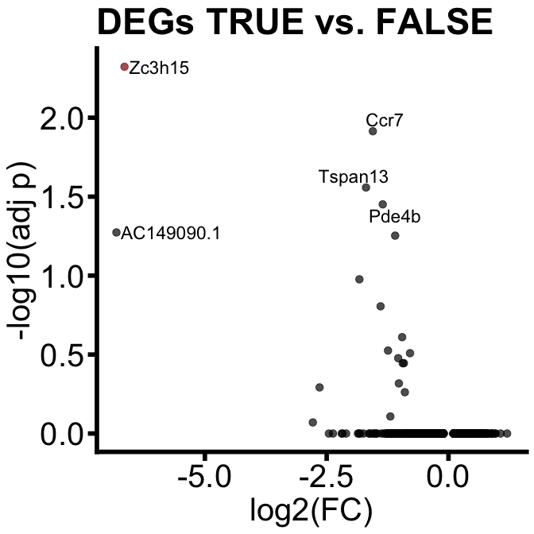

```r
DE_byexpansion[[2]]
```

## 9 Version information

[session information not shown]